# Assigning ASVs with DADA2

Ezra Seckin

April 21, 2026

# Goals

1. Infer an error model for in the filtered sequences, separately on forward and reverse reads.
2. Assign ASVs on both forward and reverse reads separately by applying the error model.
3. Merge forward and reverse ASVs into “contiguous ASVs”.
4. Generate the first draft of ASV count table.
5. Quality Trimming of ASV lengths.
6. Remove chimeras.
7. Assign Taxonomy with Silva Database.
8. Write out relevant files: `asv_table`, `asvs_fasta`, `tax_table`, and `sample_data`.
9. Create a **S4** R data object, which in this case is known as a phyloseq, object from the `asv_table`, `tax_table`, and metadata. This will give us one data object to work with moving forward. :)

## Input

1. Filtered fastq files generated from `01_QualityTrimming.Rmd`.
2. Sample Name vector.

## Output

1. ASV Count Table: `asv_table` (with and without sequence names)
2. ASV fasta file: `asvs_fasta` for building a phylogenetic tree at a later step.
3. Taxonomy Table `tax_table`
4. Sample Information: `sample_data` track the reads lots throughout DADA2 workflow.

# Set up the Environment

## Set Seed & Threads

We need to be mindful of others when we are using the server. We learned in this lesson that we can use `top` and `htop` in the shell to see how many users are currently on the server. So, if you’re working through something outside of class, it’s ok to increase the number of threads. And, it will make everything go faster!

Then, when we have a `multithread` parameter, we can set it to be `multithread = n_threads`. If we notice more people on the server, we can modify the n_threads in this one location.

```r
# Set the seed for reproducibility
set.seed(238428)

# Let's make a parameter to set the number of threads
n_threads = 200
```

## Timing of this script

Let’s record how long this file took to run on the class server, which we will record at the end of the script.

```r
# What time did we start running this script?
start_time <- Sys.time()
```

## Load Packages

```r
# Efficient package loading with pacman
pacman::p_load(tidyverse, devtools, dada2, phyloseq,
               patchwork, DT, install = FALSE)
```

## Load Filtered Fastq Files

```r
# Place filtered seq files into a variable
filtered_fastqs_path <- "data/01_QualityTrimming/filtered_fastqs"

# Intuition check:
filtered_fastqs_path
```

```
## [1] "data/01_QualityTrimming/filtered_fastqs"
```

```r
# Create Forward vector
filtered_forward_reads <-
  list.files(filtered_fastqs_path, pattern = "R1_filtered.fastq.gz",
             full.names = TRUE)
# Check
filtered_forward_reads[1:5]
```

```
## [1] "data/01_QualityTrimming/filtered_fastqs/SRR3666998_R1_filtered.fastq.gz"
## [2] "data/01_QualityTrimming/filtered_fastqs/SRR3666999_R1_filtered.fastq.gz"
## [3] "data/01_QualityTrimming/filtered_fastqs/SRR3667000_R1_filtered.fastq.gz"
## [4] "data/01_QualityTrimming/filtered_fastqs/SRR3667001_R1_filtered.fastq.gz"
## [5] "data/01_QualityTrimming/filtered_fastqs/SRR3667002_R1_filtered.fastq.gz"
```

```r
# Reverse vector
filtered_reverse_reads <-
    list.files(filtered_fastqs_path, pattern = "R2_filtered.fastq.gz",
             full.names = TRUE)

# Check
filtered_reverse_reads[1:5]
```

```
## [1] "data/01_QualityTrimming/filtered_fastqs/SRR3666998_R2_filtered.fastq.gz"
## [2] "data/01_QualityTrimming/filtered_fastqs/SRR3666999_R2_filtered.fastq.gz"
## [3] "data/01_QualityTrimming/filtered_fastqs/SRR3667000_R2_filtered.fastq.gz"
## [4] "data/01_QualityTrimming/filtered_fastqs/SRR3667001_R2_filtered.fastq.gz"
## [5] "data/01_QualityTrimming/filtered_fastqs/SRR3667002_R2_filtered.fastq.gz"
```

## Sample Names

```r
# Create vector of sample names from the filenames
sample_names <- sapply(strsplit(basename(filtered_forward_reads), "_"), `[`,1)

# Intuition Check
head(sample_names)
```

```
## [1] "SRR3666998" "SRR3666999" "SRR3667000" "SRR3667001" "SRR3667002"
## [6] "SRR3667003"
```

# Error Modelling

## How does it work?

This is the step along the workflow where we try to estimate what is a *mistake* from technological sequencing error versus what is *true biological variation*. Therefore, this step is another critical step that we need to be mindful of! This is also what makes DADA2 unique!

Specifically, we will infer error rates for all possible *transitions* within purines and pyrimidines (A<>G or C<>T) and *transversions* between all purine and pyrimidine combinations. The error model is learned by alternating estimation of the error rates and inference of sample composition until they converge. It starts with abundant sequences first and then goes to less abundant sequences. It will:

1. Starts with the assumption that the error rates are the maximum (takes the most abundant sequence (“center”) and assumes it’s the only sequence not caused by errors).
2. Compares the other sequences to the most abundant sequence.
3. Uses at most 10<sup>8</sup> nucleotides for the error estimation. (Though, sometimes we increase this parameter in the case of binned sequencing quality scores.)
4. Uses parametric error estimation function of loess fit on the observed error rates.

## Important Notes

**First, every individual sequencing run needs to have it’s own and separate error model!** This is because every sequencing run is unique—even if the flow cell and DNA/samples are *exactly the same*.

While you can combine multiple datasets together after running them through DADA2, if you’d like to limit bias and combine data sets from multiple sequencing runs, it is ideal to do the following:

1. Use the exact same DNA extractions and library prep (*e.g.* same primer sets).
2. Perform the exact same `filterAndTrim()`, with equivalent parameters between sequencing runs. This is because we need to have the exact same ASV length expected by the output of our filtering and trimming.
3. Assign ASVs on forward and reverse reads, merge them, and then once you have the ASV table from each sequencing run, you can merge them together.

But wait: *What contributes to sequencing error in different sequencing runs and why do we need to model errors separately per run with `learnErrors()` in dada2?* Remember the core principles of how Illumina sequencing works! Some things that contribute to this are:

1. Each sequencing run has a **unique timing for when clusters go out of sync** (*e.g.,* the drop in quality at end of reads, which is typical of Illumina sequencing. This decrease in read quality is especially true of older Illumina sequencing data and is improving with more recent technologies.
2. The **cluster density is impossible to replicate**. Therefore, the cluster density (and therefore sequence quality) will always be different between sequencing runs (even if it’s the same person/samples/sequencing facility!). This is getting easier to replicate with the newer flow cells (*e.g.,* patterned flow cells) but is not yet possible.
3. **PhiX spike-in will also vary between runs**, even if we try to make it the same! Therefore, the amount of heterogeneity on the flow cell will also be different, which further impacting the sequencing quality.
4. **Different locations on the flow cell can be impacted differently between runs.** Perhaps an air bubble can get in. Or, as mentioned above, the cluster density is higher and/or lower on a different run/flow cell. In the old, non-patterned flow cells, sometimes clusters can form nearby each other. However, this has been solved on the new, patterned flow cells where clusters have a specific distance between each other.

**Second, this step uses our quality scores, which is rapidly changing with new sequencing technologies!** Therefore, we need to be mindful of how we run our error models. The traditional error models were developed based on the 40 Phred scores that were generated by early Illumina Sequencing technologies. However, with the new binned quality scores, we need to incorporate new ways of error modeling and this is constanstly changing right now, which you can see in this [very active discussion on the DADA2 GitHub page](https://github.com/benjjneb/dada2/issues/1307).

Now, let’s consider the two types of Illumina data output and how it might inform our error modeling.

## Learn the Errors

### MiSeq Runs: 40 Phred Scores

Here, in the data we have sequenced here, we have Illumina MiSeq data with the traditional 40 Phred scores. Therefore, we can use the traditional `learnErrors()` command, which we will do below.

```r
# Forward Reads
error_forward_reads <-
  learnErrors(filtered_forward_reads, multithread = n_threads)
```

```
## 134584296 total bases in 590282 reads from 3 samples will be used for learning the error rates.
```

```r
# Forward Error Plot
forward_error_plot <-
  plotErrors(error_forward_reads, nominalQ = TRUE) +
  labs(title = "Forward Reads: Error Model")

# Reverse Reads
error_reverse_reads <-
  learnErrors(filtered_reverse_reads, multithread = n_threads)
```

```
## 132813450 total bases in 590282 reads from 3 samples will be used for learning the error rates.
```

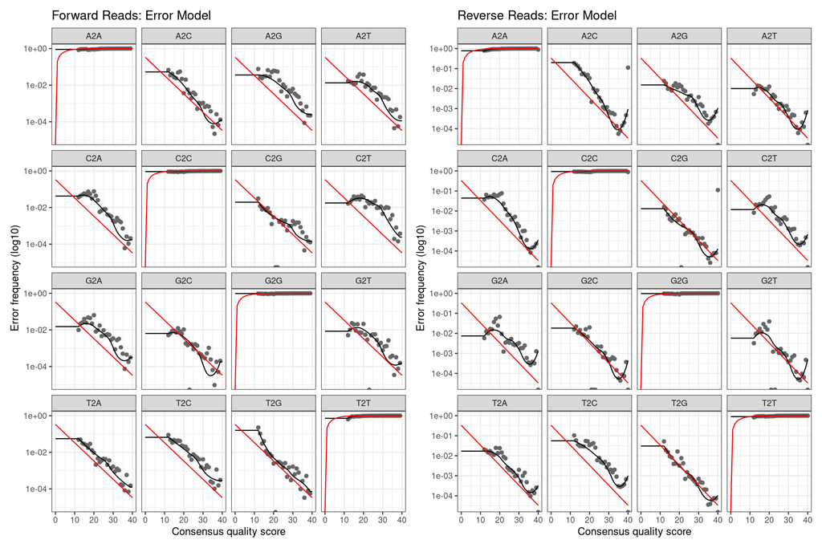

```r
# Reverse Error Plot
reverse_error_plot <-
  plotErrors(error_reverse_reads, nominalQ = TRUE) +
  labs(title = "Reverse Reads: Error Model")

# Look at the plots together
forward_error_plot + reverse_error_plot
```

The above plot represents the error rates for each possible transition (A→C, A→G, …) in the forward reads (on the left) and the reverse reads (on the right).

Details of the plots above: - **Points**: The observed error rates for each consensus quality score.  
- **Black line**: Estimated error rates after convergence of the machine-learning algorithm.  
- **Red line:** The error rates expected under the nominal definition of the Q-score.

Similar to what is mentioned in the [DADA2 tutorial](https://benjjneb.github.io/dada2/tutorial_1_8.html): the estimated error rates (black line) are a “reasonably good” fit to the observed rates (points), and the error rates drop with increased quality as expected. We can now infer ASVs!

# Infer ASVs

**An important note:** What makes DADA2 so nice is that it infers ASVs separately on the forward and the reverse reads and then merges them afterwards. This is quite a different approach from how OTUs are identified in Mothur and also from UCHIME, oligotyping, and other OTU, MED, and ASV approaches.

```r
# Infer ASVs on the forward sequences
dada_forward <-
  dada(filtered_forward_reads,
       err = error_forward_reads,
       multithread = n_threads)
```

```
## Sample 1 - 231005 reads in 24431 unique sequences.
## Sample 2 - 154065 reads in 7956 unique sequences.
## Sample 3 - 205212 reads in 12271 unique sequences.
## Sample 4 - 152270 reads in 11852 unique sequences.
## Sample 5 - 116829 reads in 7804 unique sequences.
## Sample 6 - 113628 reads in 11262 unique sequences.
## Sample 7 - 228714 reads in 12877 unique sequences.
## Sample 8 - 88412 reads in 3890 unique sequences.
## Sample 9 - 100549 reads in 12846 unique sequences.
## Sample 10 - 187893 reads in 9030 unique sequences.
## Sample 11 - 144556 reads in 7692 unique sequences.
## Sample 12 - 155442 reads in 28282 unique sequences.
## Sample 13 - 167045 reads in 8516 unique sequences.
## Sample 14 - 222356 reads in 8636 unique sequences.
## Sample 15 - 185381 reads in 11041 unique sequences.
## Sample 16 - 144641 reads in 12321 unique sequences.
## Sample 17 - 203594 reads in 15807 unique sequences.
## Sample 18 - 115745 reads in 6529 unique sequences.
## Sample 19 - 92994 reads in 6032 unique sequences.
## Sample 20 - 96085 reads in 7038 unique sequences.
## Sample 21 - 153098 reads in 7702 unique sequences.
## Sample 22 - 209990 reads in 11867 unique sequences.
## Sample 23 - 203380 reads in 25490 unique sequences.
## Sample 24 - 132040 reads in 6970 unique sequences.
## Sample 25 - 200899 reads in 11755 unique sequences.
## Sample 26 - 140672 reads in 21734 unique sequences.
## Sample 27 - 99005 reads in 16495 unique sequences.
## Sample 28 - 86817 reads in 7810 unique sequences.
## Sample 29 - 125280 reads in 8564 unique sequences.
## Sample 30 - 128373 reads in 5548 unique sequences.
## Sample 31 - 190524 reads in 30259 unique sequences.
## Sample 32 - 80596 reads in 4207 unique sequences.
## Sample 33 - 93256 reads in 4958 unique sequences.
## Sample 34 - 83175 reads in 3114 unique sequences.
## Sample 35 - 135403 reads in 7364 unique sequences.
## Sample 36 - 121804 reads in 8177 unique sequences.
## Sample 37 - 119118 reads in 6474 unique sequences.
## Sample 38 - 80875 reads in 6500 unique sequences.
## Sample 39 - 165857 reads in 37850 unique sequences.
## Sample 40 - 210264 reads in 13016 unique sequences.
## Sample 41 - 89727 reads in 5018 unique sequences.
## Sample 42 - 135315 reads in 11892 unique sequences.
## Sample 43 - 221742 reads in 7884 unique sequences.
```

```r
# Take a look at the data
# What type of data structure is it?
typeof(dada_forward) # It's a list
```

```
## [1] "list"
```

```r
length(dada_forward) # How big is it? One per sample!
```

```
## [1] 43
```

```r
# What does it look like for each sample?
dada_forward$`SRR3667040_R2_filtered.fastq`
```

[output not shown]

```r
# Reverse ASVs
dada_reverse <-
  dada(filtered_reverse_reads,
       err = error_reverse_reads ,
       multithread = n_threads)
```

```
## Sample 1 - 231005 reads in 26357 unique sequences.
## Sample 2 - 154065 reads in 8991 unique sequences.
## Sample 3 - 205212 reads in 17610 unique sequences.
## Sample 4 - 152270 reads in 13311 unique sequences.
## Sample 5 - 116829 reads in 8755 unique sequences.
## Sample 6 - 113628 reads in 11444 unique sequences.
## Sample 7 - 228714 reads in 19507 unique sequences.
## Sample 8 - 88412 reads in 4439 unique sequences.
## Sample 9 - 100549 reads in 12444 unique sequences.
## Sample 10 - 187893 reads in 9810 unique sequences.
## Sample 11 - 144556 reads in 10356 unique sequences.
## Sample 12 - 155442 reads in 28472 unique sequences.
## Sample 13 - 167045 reads in 11249 unique sequences.
## Sample 14 - 222356 reads in 8961 unique sequences.
## Sample 15 - 185381 reads in 14192 unique sequences.
## Sample 16 - 144641 reads in 13056 unique sequences.
## Sample 17 - 203594 reads in 16232 unique sequences.
## Sample 18 - 115745 reads in 9681 unique sequences.
## Sample 19 - 92994 reads in 7807 unique sequences.
## Sample 20 - 96085 reads in 13064 unique sequences.
## Sample 21 - 153098 reads in 10345 unique sequences.
## Sample 22 - 209990 reads in 15182 unique sequences.
## Sample 23 - 203380 reads in 28049 unique sequences.
## Sample 24 - 132040 reads in 8720 unique sequences.
## Sample 25 - 200899 reads in 13627 unique sequences.
## Sample 26 - 140672 reads in 23097 unique sequences.
## Sample 27 - 99005 reads in 16333 unique sequences.
## Sample 28 - 86817 reads in 9959 unique sequences.
## Sample 29 - 125280 reads in 9751 unique sequences.
## Sample 30 - 128373 reads in 6159 unique sequences.
## Sample 31 - 190524 reads in 28475 unique sequences.
## Sample 32 - 80596 reads in 5348 unique sequences.
## Sample 33 - 93256 reads in 5157 unique sequences.
## Sample 34 - 83175 reads in 3796 unique sequences.
## Sample 35 - 135403 reads in 7890 unique sequences.
## Sample 36 - 121804 reads in 8811 unique sequences.
## Sample 37 - 119118 reads in 6992 unique sequences.
## Sample 38 - 80875 reads in 8599 unique sequences.
## Sample 39 - 165857 reads in 38532 unique sequences.
## Sample 40 - 210264 reads in 27334 unique sequences.
## Sample 41 - 89727 reads in 5551 unique sequences.
## Sample 42 - 135315 reads in 12805 unique sequences.
## Sample 43 - 221742 reads in 10446 unique sequences.
```

```r
# Check data
dada_reverse[30]
```

```
## $SRR3667031_R2_filtered.fastq.gz
## dada-class: object describing DADA2 denoising results
## 302 sequence variants were inferred from 6159 input unique sequences.
## Key parameters: OMEGA_A = 1e-40, OMEGA_C = 1e-40, BAND_SIZE = 16
```

# Merge Forward and Reverse ASVs

Now, that we have identified our ASVs separately on both the forward and the reverse reads, let’s **merge** them together into contiguous (*aka* “contigs”) ASVs.

```r
merged_ASVs <-
  mergePairs(dada_forward, filtered_forward_reads,
             dada_reverse, filtered_reverse_reads,
             verbose = TRUE)
```

```
## 218026 paired-reads (in 4176 unique pairings) successfully merged out of 226521 (in 10313 pairings) input.
```

```
## 153956 paired-reads (in 379 unique pairings) successfully merged out of 154011 (in 413 pairings) input.
```

```
## 201742 paired-reads (in 791 unique pairings) successfully merged out of 204055 (in 2194 pairings) input.
```

```
## 146867 paired-reads (in 1098 unique pairings) successfully merged out of 150429 (in 3188 pairings) input.
```

```
## 114221 paired-reads (in 902 unique pairings) successfully merged out of 115739 (in 1808 pairings) input.
```

```
## 107892 paired-reads (in 1430 unique pairings) successfully merged out of 111502 (in 3838 pairings) input.
```

```
## 227420 paired-reads (in 1479 unique pairings) successfully merged out of 228160 (in 1868 pairings) input.
```

```
## 88327 paired-reads (in 251 unique pairings) successfully merged out of 88341 (in 257 pairings) input.
```

```
## 91899 paired-reads (in 2308 unique pairings) successfully merged out of 97356 (in 5587 pairings) input.
```

```
## 187003 paired-reads (in 447 unique pairings) successfully merged out of 187509 (in 791 pairings) input.
```

```
## 144437 paired-reads (in 437 unique pairings) successfully merged out of 144461 (in 455 pairings) input.
```

```
## 131802 paired-reads (in 5440 unique pairings) successfully merged out of 146740 (in 16682 pairings) input.
```

```
## 166514 paired-reads (in 658 unique pairings) successfully merged out of 166731 (in 766 pairings) input.
```

```
## 222074 paired-reads (in 361 unique pairings) successfully merged out of 222205 (in 429 pairings) input.
```

```
## 184683 paired-reads (in 1213 unique pairings) successfully merged out of 184952 (in 1404 pairings) input.
```

```
## 137623 paired-reads (in 2335 unique pairings) successfully merged out of 141714 (in 4731 pairings) input.
```

```
## 195909 paired-reads (in 2862 unique pairings) successfully merged out of 200804 (in 6042 pairings) input.
```

```
## 114722 paired-reads (in 515 unique pairings) successfully merged out of 115208 (in 794 pairings) input.
```

```
## 92515 paired-reads (in 792 unique pairings) successfully merged out of 92775 (in 915 pairings) input.
```

```
## 93253 paired-reads (in 757 unique pairings) successfully merged out of 94912 (in 1876 pairings) input.
```

```
## 151957 paired-reads (in 1114 unique pairings) successfully merged out of 152499 (in 1436 pairings) input.
```

```
## 208865 paired-reads (in 1286 unique pairings) successfully merged out of 209489 (in 1640 pairings) input.
```

```
## 186567 paired-reads (in 5436 unique pairings) successfully merged out of 196993 (in 13291 pairings) input.
```

```
## 129404 paired-reads (in 1139 unique pairings) successfully merged out of 130865 (in 1986 pairings) input.
```

```
## 199161 paired-reads (in 707 unique pairings) successfully merged out of 200030 (in 1279 pairings) input.
```

```
## 123403 paired-reads (in 4363 unique pairings) successfully merged out of 133536 (in 11289 pairings) input.
```

```
## 86992 paired-reads (in 3152 unique pairings) successfully merged out of 94645 (in 8335 pairings) input.
```

```
## 82616 paired-reads (in 944 unique pairings) successfully merged out of 85163 (in 2645 pairings) input.
```

```
## 121591 paired-reads (in 1233 unique pairings) successfully merged out of 123915 (in 2607 pairings) input.
```

```
## 128139 paired-reads (in 396 unique pairings) successfully merged out of 128284 (in 424 pairings) input.
```

```
## 168077 paired-reads (in 5820 unique pairings) successfully merged out of 182695 (in 16459 pairings) input.
```

```
## 80125 paired-reads (in 312 unique pairings) successfully merged out of 80334 (in 424 pairings) input.
```

```
## 92922 paired-reads (in 336 unique pairings) successfully merged out of 93019 (in 386 pairings) input.
```

```
## 83064 paired-reads (in 208 unique pairings) successfully merged out of 83077 (in 219 pairings) input.
```

```
## 135295 paired-reads (in 298 unique pairings) successfully merged out of 135346 (in 320 pairings) input.
```

```
## 118315 paired-reads (in 1146 unique pairings) successfully merged out of 120535 (in 2385 pairings) input.
```

```
## 117167 paired-reads (in 727 unique pairings) successfully merged out of 118290 (in 1307 pairings) input.
```

```
## 78051 paired-reads (in 844 unique pairings) successfully merged out of 79869 (in 1937 pairings) input.
```

```
## 132434 paired-reads (in 7698 unique pairings) successfully merged out of 153257 (in 23074 pairings) input.
```

```
## 207484 paired-reads (in 2077 unique pairings) successfully merged out of 209160 (in 3248 pairings) input.
```

```
## 89473 paired-reads (in 339 unique pairings) successfully merged out of 89592 (in 376 pairings) input.
```

```
## 127913 paired-reads (in 2199 unique pairings) successfully merged out of 132618 (in 5457 pairings) input.
```

```
## 221230 paired-reads (in 454 unique pairings) successfully merged out of 221472 (in 614 pairings) input.
```

```r
# Evaluate the data output
typeof(merged_ASVs) # A list
```

```
## [1] "list"
```

```r
length(merged_ASVs) # Length of the number of samples!
```

```
## [1] 43
```

```r
head(names(merged_ASVs)) # Here, we can access our current sample names
```

```
## [1] "SRR3666998_R1_filtered.fastq.gz" "SRR3666999_R1_filtered.fastq.gz"
## [3] "SRR3667000_R1_filtered.fastq.gz" "SRR3667001_R1_filtered.fastq.gz"
## [5] "SRR3667002_R1_filtered.fastq.gz" "SRR3667003_R1_filtered.fastq.gz"
```

```r
# Inspect further for each sample
#head(merged_ASVs, n = 2) # A dataframe for each sample
# We have a dataframe in each part of our list! What are in the columns?
glimpse(merged_ASVs$`SRR3667040_R1_filtered.fastq`)
```

```
## Rows: 7,698
## Columns: 9
## $ sequence  <chr> "TCGAGAATCATTCACAATGGGGGAAACCCTGATGGTGCGACGCCGCGTGGGGGAATGAA…
## $ abundance <int> 5420, 4448, 2638, 2305, 2098, 2064, 2058, 1903, 1727, 1527, …
## $ forward   <int> 1, 2, 4, 3, 9, 7, 5, 6, 8, 13, 10, 14, 12, 15, 11, 16, 21, 1…
## $ reverse   <int> 1, 3, 2, 4, 7, 10, 6, 8, 5, 14, 13, 11, 15, 17, 12, 2, 23, 4…
## $ nmatch    <int> 45, 26, 32, 52, 31, 50, 48, 49, 31, 45, 26, 51, 26, 51, 26, …
## $ nmismatch <int> 0, 0, 0, 0, 0, 0, 0, 0, 0, 0, 0, 0, 0, 0, 0, 0, 0, 0, 0, 0, …
## $ nindel    <int> 0, 0, 0, 0, 0, 0, 0, 0, 0, 0, 0, 0, 0, 0, 0, 0, 0, 0, 0, 0, …
## $ prefer    <dbl> 1, 1, 2, 2, 2, 1, 1, 1, 2, 1, 1, 2, 1, 1, 1, 2, 2, 2, 1, 2, …
## $ accept    <lgl> TRUE, TRUE, TRUE, TRUE, TRUE, TRUE, TRUE, TRUE, TRUE, TRUE, …
```

# Create Raw ASV Count Table

```r
# Raw ASV
raw_ASV_table <- makeSequenceTable(merged_ASVs)

# Intuition Check: Type and dimensions of the data
dim(raw_ASV_table)
```

```
## [1]    43 41447
```

```r
typeof(raw_ASV_table)
```

```
## [1] "integer"
```

```r
class(raw_ASV_table)
```

```
## [1] "matrix" "array"
```

```r
# write out raw_asv_table
write.table(raw_ASV_table, file = "data/02_AssignASVs/raw_ASV_counts.tsv",
            sep = "\t", quote = FALSE, col.names = NA)
```

# Assess ASV Quality

## What are the current ASV lengths?

First, let’s inspect the distribution of the ASV sequence lengths across all of the ASVs that we have inferred. First, we need to consider: **What is the expected length of the ASVs?**

INTERPRETATION #1: Hypothesized ASV Length

What is the sequencing strategy?

Paired-end 250 bp (2×250 bp) Illumina MiSeq sequencing was used, targeting the V4 hypervariable region of the 16S rRNA gene with the 515F and 806R primers.

What’s the total length of our starting amplicons?

Our primers are named after the position they bind to on the 16S gene. So: 806 - 515 = 291 The total length of the starting amplicon is 291 base pairs, including primers.

What is the expected ASV length without primers?

The 515F primer (GTGYCAGCMGCCGCGGTAA) is 19 base pairs. The 806R primer (GGACTACNVGGGTWTCTAAT) is 20 base pairs. 291 - 19 - 20 = 252 The expected ASV length without primers is 252 base pairs. IMPORTANT: Unlike the in-class dataset (which used the Kozich et al., 2013 library prep and did not sequence the primers), our dataset used the standard Illumina 2-step PCR library preparation, meaning the primers were present in the raw sequences. They were subsequently identified and removed using Cutadapt in 01_QualityTrimming.Rmd, leaving us with reads of ~230 bp going into filterAndTrim().

What is the expected ASV length after filterAndTrim()?

After Cutadapt primer removal, our reads were ~230 bp long. In 01_QualityTrimming.Rmd, we used truncLen = c(228, 225) — trimming 2 bp from the forward read and 5 bp from the reverse read to remove low-quality tails. Since DADA2 merges forward and reverse reads into a single contiguous ASV, the final ASV length is determined by the amplicon itself (252 bp), not the individual read lengths — as long as there is sufficient overlap. The expected merged ASV length is therefore approximately 252 bp.

What is the expected overlap between forward and reverse reads?

Our forward reads are 228 bp and our reverse reads are 225 bp after filterAndTrim(). Combined read length: 228 + 225 = 453 bp Expected amplicon length (without primers): 252 bp Expected overlap: 453 - 252 = 201 bp This is a very substantial overlap (~80% of the amplicon length), which is excellent. A minimum of 12–20 bp of overlap is required for DADA2 to merge reads successfully, so 201 bp of overlap gives us a very high confidence in accurate merging and ASV assignment.

### ASV Length Stats

```r
# Calculate summary stats
# Longest ASV?
maxLength_ASV <- max(nchar(getSequences(raw_ASV_table)))

# Shortest ASV?
minLength_ASV <- min(nchar(getSequences(raw_ASV_table)))

# Mean ASV length?
meanLength_ASV <- mean(nchar(getSequences(raw_ASV_table)))

# Median ASV length?
medianLength_ASV <- median(nchar(getSequences(raw_ASV_table)))

# Create a table to Inspect the distribution of sequence lengths of all ASVs in dataset
table(nchar(getSequences(raw_ASV_table)))
```

```
##
##  228  230  233  238  239  242  243  244  245  246  247  248  251  252  253  255
##    3    3    1    1    1    2    4    1    1    1    3    1    2    1    1    2
##  256  257  258  259  260  261  262  264  265  267  268  269  270  274  276  280
##    1    4    1    2    8    2    1    1    1    2    1    1    1    4    2    3
##  287  289  290  291  292  293  296  297  300  301  302  304  305  308  309  310
##    1    3    2    1    4    1    2    1    2    1    3    1    1    1    1    1
##  311  315  316  319  320  323  324  325  333  335  336  337  339  340  341  342
##    1    3    1    2    1    2   29    4    1    3    2    2    1    4    3    2
##  343  349  350  353  358  359  360  361  362  363  364  366  369  371  372  374
##    6    3    6    1    4    2    1    1    2    7    1    8    1    5    7    3
##  376  380  382  384  385  386  387  388  389  390  393  395  397  398  400  401
##    1    3    3    8    2    7    3    5    1    1    1    1    1    1   73 2179
##  402  403  404  405  406  407  408  409  410  411  412  413  414  415  416  417
## 5707 1207 2788 2939  664  483  464  182   44  113   10   14   22   12   44   12
##  418  419  420  421  422  423  424  425  426  427  428  429  430  438
##   58  198  155 1465 9063 1606   32   40 1040 8128 2375   73   10    1
```

Here’s some of the stats that we’ve calculated:

- Max ASV length: 438 base pairs
- Min ASV length: 228 base pairs
- Mean ASV length: 415.2560861 base pairs
- Median ASV length: 422 base pairs

### ASV Length Plot

Now, we will plot these ASV lengths to give us a better idea:

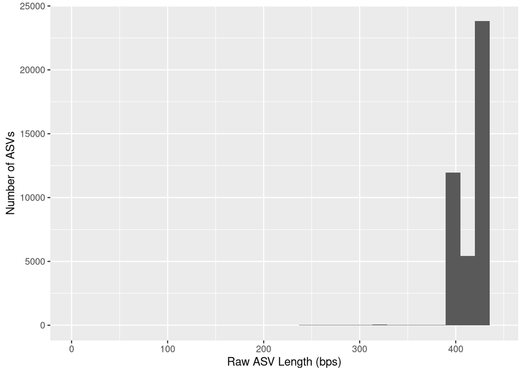

```r
# Inspect the distribution of sequence lengths of all ASVs in data set
# AFTER TRIM
plot_ASVLength_raw <-
  data.frame(Seq_Length = nchar(getSequences(raw_ASV_table))) %>%
  ggplot(aes(x = Seq_Length )) +
  geom_histogram() +
  # include the x-axis scales
  scale_x_continuous(limits = c(0, maxLength_ASV + 5)) +
  labs(y = "Number of ASVs", x = "Raw ASV Length (bps)")

# Show the plot
plot_ASVLength_raw
```

## Trim ASV lengths

**NOTE:** This is another moment in our workflow where we are sub-setting only the “good parts” of our data to ensure the data quality we have at the end is the best of our ability based on the sequencing run.

```r
# Subset only ASVs that are between 400 and 430 bps long
raw_ASV_table_trimmed <-
  raw_ASV_table[, nchar(colnames(raw_ASV_table)) %in% 400:430]

# Inspect the distribution of sequence lengths of all ASVs in dataset
table(nchar(getSequences(raw_ASV_table_trimmed)))
```

```
##
##  400  401  402  403  404  405  406  407  408  409  410  411  412  413  414  415
##   73 2179 5707 1207 2788 2939  664  483  464  182   44  113   10   14   22   12
##  416  417  418  419  420  421  422  423  424  425  426  427  428  429  430
##   44   12   58  198  155 1465 9063 1606   32   40 1040 8128 2375   73   10
```

```r
# What proportion of total ASV sequences are left in the data?
percRetained_Trimmed <- sum(raw_ASV_table_trimmed)/sum(raw_ASV_table)
percRetained_Trimmed # Show it
```

```
## [1] 0.9975325
```

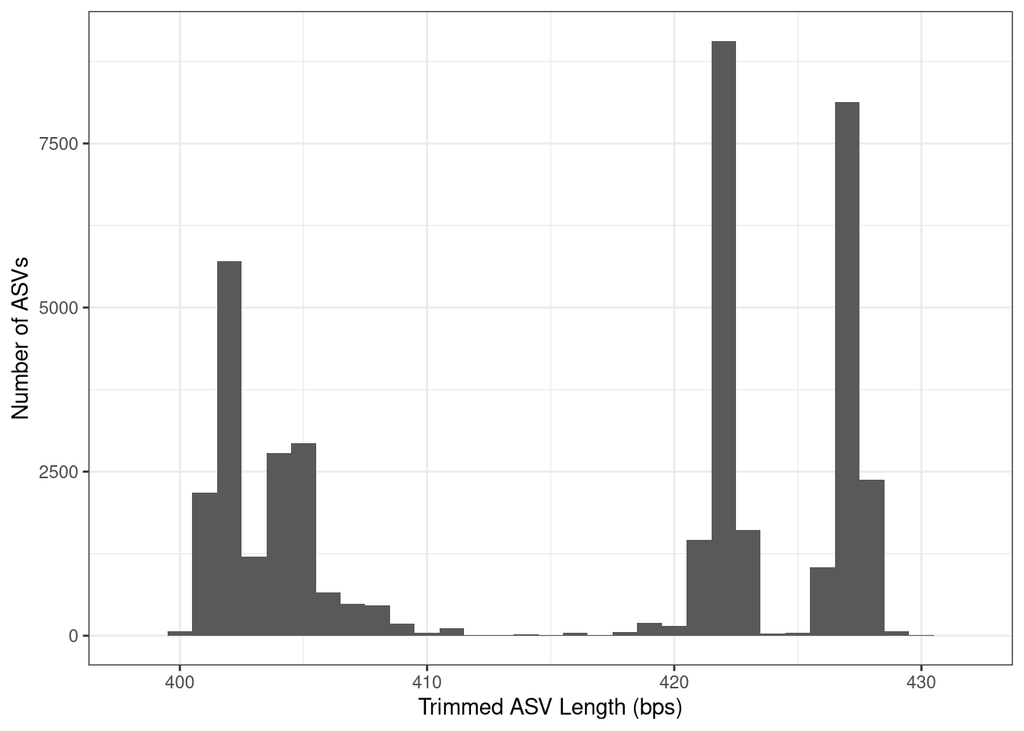

```r
# Inspect the distribution of sequence lengths of all ASVs in dataset
# AFTER TRIM
plot_ASVLength_trimmed <-
  data.frame(Seq_Length = nchar(getSequences(raw_ASV_table_trimmed))) %>%
  ggplot(aes(x = Seq_Length)) +
  geom_histogram(binwidth = 1) +   # binwidth = 1 to show each bp individually
  scale_x_continuous(limits = c(398, 432)) +  # ← zoomed in to your retained range
  labs(y = "Number of ASVs", x = "Trimmed ASV Length (bps)") +
  theme_bw()

# Show the plot
plot_ASVLength_trimmed
```

# Remove Chimeras

## What is a chimera?

In 16S rRNA gene sequencing, a **chimera** is an artificial DNA sequence that forms when two or more different DNA templates are mistakenly and erroneously fused together during PCR amplification. **Chimeric sequences do not represent real organisms and must be removed during data processing to avoid false species identifications!** Chimeras are natural artifacts in PCR, especially in high-cycle (>25 cycle) PCR reactions, which are typical in library preparation and sequencing workflows. They arise during:

1. *Incomplete Extension in Early PCR Cycles.* During early PCR cycles, a DNA fragment may partially amplify before the polymerase detaches. This incomplete product remains in the reaction mixture.
2. *Template Switching in Later PCR Cycles.* In subsequent cycles, the polymerase may bind to and extend a different but similar template, rather than the original one. This results in a hybrid (chimeric) DNA molecule made of two unrelated 16S rRNA gene fragments.
3. *There is increased chimera formation in high-diversity samples.* More diverse microbial communities increase the chance of chimeric formation due to similar overlapping sequences in the sample. Longer PCR extension times and too many PCR cycles (>30) increase chimera formation by allowing more template switching.

## Chimeras must be removed

- **Chimeras create false ASVs:** Chimeric sequences do not belong to any real microbial species, leading to artificial diversity in sequencing results.
- **Chimeras can mislead ecological interpretations** If not removed, they can inflate richness estimates and misrepresent community composition.

Therefore, chimera removal is an essential step in the analysis of 16S sequencing data to improve the accuracy of downstream analyses, such as taxonomic assignment and diversity assessment. It helps to avoid the inclusion of misleading or spurious sequences that could lead to incorrect biological interpretations.

```r
# Remove the chimeras in the raw ASV table
noChimeras_ASV_table <-
  removeBimeraDenovo(raw_ASV_table_trimmed,
                     method="consensus",
                     multithread = n_threads,
                     verbose=TRUE)
```

```
## Identified 33799 bimeras out of 41200 input sequences.
```

```r
# Check the dimensions
dim(noChimeras_ASV_table)
```

```
## [1]   43 7401
```

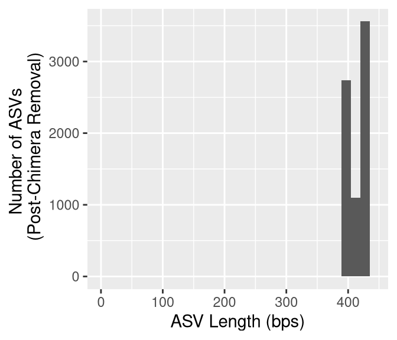

```r
# What proportion is left of the sequences?
# Chimera removal compared to trimming
percRetained_chimerasTrimmed <- sum(noChimeras_ASV_table)/sum(raw_ASV_table_trimmed)
# Chimera removal compared to raw
percRetained_chimerasRaw <-sum(noChimeras_ASV_table)/sum(raw_ASV_table)

# Plot it
plot_ASVLength_NoChimeras <-
  data.frame(Seq_Length_NoChim = nchar(getSequences(noChimeras_ASV_table))) %>%
  ggplot(aes(x = Seq_Length_NoChim )) +
  geom_histogram()+
  # include the x-axis scales
  scale_x_continuous(limits = c(0, maxLength_ASV + 5)) +
  labs(y = "Number of ASVs \n (Post-Chimera Removal)",
       x = "ASV Length (bps)")

# Show the plot
plot_ASVLength_NoChimeras
```

1. 99.75% of the raw ASVs were retained *after trimming*.
2. 92.33% of the trimmed ASV counts were retained *after chimera removal*.
3. This translates to 92.1% retention of the original, raw merged ASV counts after *both trimming and chimera removal.*

### Plot ASV Lengths

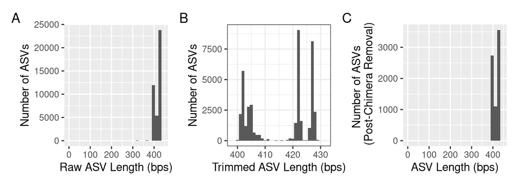

```r
plot_ASVLength_raw + plot_ASVLength_trimmed + plot_ASVLength_NoChimeras +
    plot_annotation(tag_levels = 'A')
```

# Track the read counts

Here, we will look at the number of reads that were lost in the filtering, denoising, merging, and chimera removal.

```r
# A little function to identify number seqs
getN <- function(x) sum(getUniques(x))

# Make the table to track the seqs
track <- cbind(sapply(dada_forward, getN),
               sapply(dada_reverse, getN),
               sapply(merged_ASVs, getN),
               rowSums(noChimeras_ASV_table))

head(track)
```

```
##                                   [,1]   [,2]   [,3]   [,4]
## SRR3666998_R1_filtered.fastq.gz 228553 228917 218026 192315
## SRR3666999_R1_filtered.fastq.gz 154032 154032 153956 148425
## SRR3667000_R1_filtered.fastq.gz 204634 204623 201742 196984
## SRR3667001_R1_filtered.fastq.gz 151329 151338 146867 139447
## SRR3667002_R1_filtered.fastq.gz 116305 116221 114221 105951
## SRR3667003_R1_filtered.fastq.gz 112443 112653 107892  96989
```

```r
# Update column names to be more informative (most are missing at the moment!)
colnames(track) <- c("denoisedF", "denoisedR", "merged", "nochim")
rownames(track) <- row.names(noChimeras_ASV_table)

# Generate a dataframe to track the reads through our DADA2 pipeline
track_counts_df <-
  track %>%
  # make it a dataframe
  as.data.frame() %>%
  rownames_to_column(var = "sample_names")

# Now let's add a column for the number of ASVs
# First, intuition check that the samples match
stopifnot(track_counts_df$sample_names == row.names(noChimeras_ASV_table))

# Now, let's add a new column with the number of ASVs
track_counts_df <-
  track_counts_df %>%
  mutate(num_ASVs = rowSums(noChimeras_ASV_table > 1))

# Visualize it in table format
DT::datatable(track_counts_df)
```

|  | sample_names | denoisedF | denoisedR | merged | nochim | num_ASVs |
| --- | --- | --- | --- | --- | --- | --- |
| 1 | SRR3666998_R1_filtered.fastq.gz | 228553 | 228917 | 218026 | 192315 | 1370 |
| 2 | SRR3666999_R1_filtered.fastq.gz | 154032 | 154032 | 153956 | 148425 | 346 |
| 3 | SRR3667000_R1_filtered.fastq.gz | 204634 | 204623 | 201742 | 196984 | 424 |
| 4 | SRR3667001_R1_filtered.fastq.gz | 151329 | 151338 | 146867 | 139447 | 430 |
| 5 | SRR3667002_R1_filtered.fastq.gz | 116305 | 116221 | 114221 | 105951 | 371 |
| 6 | SRR3667003_R1_filtered.fastq.gz | 112443 | 112653 | 107892 | 96989 | 341 |
| 7 | SRR3667004_R1_filtered.fastq.gz | 228542 | 228319 | 227420 | 206522 | 843 |
| 8 | SRR3667005_R1_filtered.fastq.gz | 88353 | 88394 | 88327 | 85936 | 226 |
| 9 | SRR3667006_R1_filtered.fastq.gz | 98707 | 99057 | 91899 | 76402 | 298 |
| 10 | SRR3667007_R1_filtered.fastq.gz | 187667 | 187716 | 187003 | 184589 | 378 |

[output cut: 33 more lines]

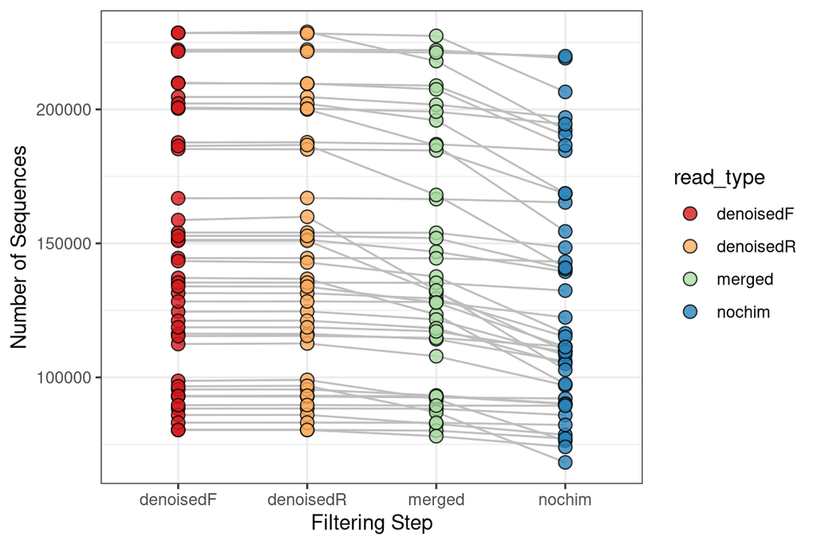

```r
# Plot it!
track_counts_df %>%
  pivot_longer(denoisedF:nochim, names_to = "read_type", values_to = "num_reads") %>%
  mutate(read_type = fct_relevel(read_type, "denoisedF", "denoisedR", "merged", "nochim")) %>%
  ggplot(aes(x = read_type, y = num_reads, fill = read_type)) +
  geom_line(aes(group = sample_names), color = "grey") +
  geom_point(shape = 21, size = 3, alpha = 0.8) +
  scale_fill_brewer(palette = "Spectral") +
  labs(x = "Filtering Step", y = "Number of Sequences") +
  theme_bw()
```

Now, let’s plot the number of sequences that have been maintained in our samples using `geom_histogram()`.

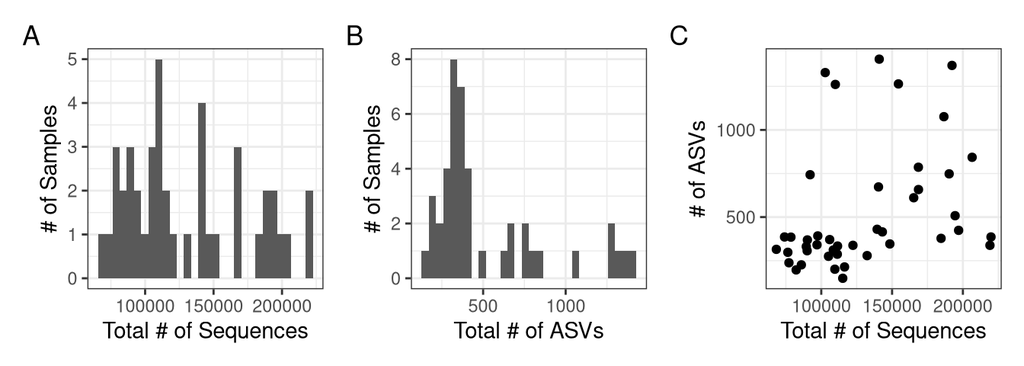

```r
plot_ReadDepth <-
  track_counts_df %>%
  ggplot(aes(x = nochim)) +
  geom_histogram() +
  labs(x = "Total # of Sequences", y = "# of Samples") +
  theme_bw()

# What is the ASV richness per sample?
plot_ASVRichness <-
  track_counts_df %>%
  ggplot(aes(x = num_ASVs)) +
  geom_histogram() +
  labs(x = "Total # of ASVs", y = "# of Samples") +
  theme_bw()

# Now, let's look at the relationship of ASVs and Sequencing depth
plot_ReadDepth_ASVRichness <-
  track_counts_df %>%
  ggplot(aes(x = nochim, y = num_ASVs)) +
  geom_point() +
  labs(x = "Total # of Sequences", y = "# of ASVs") +
  theme_bw()

# Show the plots together
plot_ReadDepth + plot_ASVRichness + plot_ReadDepth_ASVRichness +
    plot_annotation(tag_levels = 'A')
```

The figure above consists of three plots that summarize sequencing depth, ASV richness, and their relationship after DADA2 processing of 16S rRNA gene sequencing data.

**Panel A: Read Depth after DADA2:** Histogram of sequencing depth per sample (Total # of Sequences)

**Panel B: ASV Richness after DADA2:** Histogram of ASV richness (Total # of ASVs per sample)

**Panel C: Read Depth vs ASV Richness:** Scatter plot showing the relationship between sequencing depth and ASV richness.

- Generally there might be a positive correlation, where samples with higher read depth tend to have more ASVs. This helps show the importance of rarefaction!
- A few points deviate, particularly samples with low read depth and low ASVs, which could indicate sequencing failures, poor-quality samples, and/or negative controls.

**Overall Interpretation & Considerations**

# Assign Taxonomy

Here, we will use the **silva database version 138.2**, which has been properly formatted for DADA2. The files came from this [DADA2-formatted reference databases website](https://benjjneb.github.io/dada2/training.html), which hosts several other reference taxomoy files for several popular taxonomic databases.

In this example, we are going to use the database that is pre-downloaded to the server at the following path: `/workdir/in_class_data/taxonomy/`. You are welcome to symbolically link the taxonomy files, however note that they are VERY LARGE. So, it is actually suggested here (for this one time) to use the absolute path here. However, we need to note that this would break our reproducibility!

## How does the taxonomy work?

The `assignTaxonomy` function implements the Ribosomal Database Project (RDP) Naive Bayesian Classifier algorithm described in Wang et al. (2007), published in Applied and Environmental Microbiology, with a kmer size of 8 and 100 bootstrap replicates.

```r
# Assign up to genus level
taxa_train <-
  assignTaxonomy(noChimeras_ASV_table,
                 refFasta = "/workdir/in_class_data/taxonomy/silva_nr99_v138.2_toGenus_trainset.fa.gz",
                 multithread = n_threads)

# Add the genus/species information
taxa_addSpecies <-
  addSpecies(taxa_train,
              refFasta = "/workdir/in_class_data/taxonomy/silva_v138.2_assignSpecies.fa.gz")

# Inspect the taxonomy
glimpse(taxa_addSpecies) # Note that the rownames are the ASV sequences!
```

```
##  chr [1:7401, 1:7] "Bacteria" "Bacteria" "Bacteria" "Bacteria" "Bacteria" ...
##  - attr(*, "dimnames")=List of 2
##   ..$ : chr [1:7401] "TGGGGAATATTGCACAATGGGCGCAAGCCTGATGCAGCCATGCCGCGTGTATGAAGAAGGCCTTCGGGTTGTAAAGTACTTTCAGCGGGGAGGAAGGGAGTAAAGTTAATA"| __truncated__ "TCGAGAATCATTCACAATGGGGGAAACCCTGATGGTGCGACGCCGCGTGGGGGAATGAAGGTCTTCGGATTGTAAACCCCTGTCATGTGGGAGCAAATTAAAAAGATAGTA"| __truncated__ "TGAGGAATATTGGTCAA…
##   ..$ : chr [1:7] "Kingdom" "Phylum" "Class" "Order" ...
```

```r
# Let's removing the ASV sequence rownames for display only
taxa_print <- taxa_addSpecies
rownames(taxa_print) <- NULL
head(taxa_print)
```

```
##      Kingdom    Phylum              Class                 Order
## [1,] "Bacteria" "Pseudomonadota"    "Gammaproteobacteria" "Enterobacterales"
## [2,] "Bacteria" "Verrucomicrobiota" "Verrucomicrobiia"    "Verrucomicrobiales"
## [3,] "Bacteria" "Bacteroidota"      "Bacteroidia"         "Bacteroidales"
## [4,] "Bacteria" "Bacteroidota"      "Bacteroidia"         "Bacteroidales"
## [5,] "Bacteria" "Fusobacteriota"    "Fusobacteriia"       "Fusobacteriales"
## [6,] "Bacteria" "Bacteroidota"      "Bacteroidia"         "Bacteroidales"
##      Family               Genus                  Species
## [1,] "Enterobacteriaceae" "Escherichia-Shigella" NA
## [2,] "Akkermansiaceae"    "Akkermansia"          "muciniphila"
## [3,] "Bacteroidaceae"     "Bacteroides"          "vulgatus"
## [4,] "Rikenellaceae"      "Alistipes"            "putredinis"
## [5,] "Fusobacteriaceae"   "Fusobacterium"        NA
## [6,] "Bacteroidaceae"     "Bacteroides"          "stercoris"
```

```r
#View(taxa_print)
```

# Export the Data

Remember from the beginning of the file under “Goals”, we wanted to export 4 different types of information:

1. ASV Count Table: `asv_table` (with and without sequence names)
2. ASV fasta file: `asvs_fasta` for building a phylogenetic tree at a later step.
3. Taxonomy Table `tax_table`
4. Sample Information: `sample_data` track the reads lots throughout DADA2 workflow.

## 1. ASV Tables

We will export the following two ASV count tables, which will be in “long” format where the **ASVs are in rows** and the **sample names are in the columns.**

### Structure of ASV tables

Let’s check that the ASVs are in the rows and the sample names are in the columns. If not, we can use the transpose function `t()` in R.

```r
# What's the current format of the ASV table?
head(rownames(noChimeras_ASV_table)) # Samples!
```

```
## [1] "SRR3666998_R1_filtered.fastq.gz" "SRR3666999_R1_filtered.fastq.gz"
## [3] "SRR3667000_R1_filtered.fastq.gz" "SRR3667001_R1_filtered.fastq.gz"
## [5] "SRR3667002_R1_filtered.fastq.gz" "SRR3667003_R1_filtered.fastq.gz"
```

```r
head(colnames(noChimeras_ASV_table)) # ASV Sequences
```

```
## [1] "TGGGGAATATTGCACAATGGGCGCAAGCCTGATGCAGCCATGCCGCGTGTATGAAGAAGG…"
## [2] "TCGAGAATCATTCACAATGGGGGAAACCCTGATGGTGCGACGCCGCGTGGGGGAATGAAG…"
## [3] "TGAGGAATATTGGTCAATGGGCGAGAGCCTGAACCAGCCAAGTAGCGTGAAGGATGACTG…"
## [4] "TGAGGAATATTGGTCAATGGACGCAAGTCTGAACCAGCCATGCCGCGTGCAGGATGACGG…"
## [5] "TGGGGAATATTGGACAATGGACCAAAAGTCTGATCCAGCAATTCTGTGTGCACGATGACG…"
## [6] "TGAGGAATATTGGTCAATGGACGAGAGTCTGAACCAGCCAAGTAGCGTGAAGGATGACTG…"
```

```r
# Therefore, we need to transpose the matrix
final_ASV_table_withSeqs <- t(noChimeras_ASV_table)

# Intuition check
head(rownames(final_ASV_table_withSeqs)) # ASV Sequences
```

```
## [1] "TGGGGAATATTGCACAATGGGCGCAAGCCTGATGCAGCCATGCCGCGTGTATGAAGAAGG…"
## [2] "TCGAGAATCATTCACAATGGGGGAAACCCTGATGGTGCGACGCCGCGTGGGGGAATGAAG…"
## [3] "TGAGGAATATTGGTCAATGGGCGAGAGCCTGAACCAGCCAAGTAGCGTGAAGGATGACTG…"
## [4] "TGAGGAATATTGGTCAATGGACGCAAGTCTGAACCAGCCATGCCGCGTGCAGGATGACGG…"
## [5] "TGGGGAATATTGGACAATGGACCAAAAGTCTGATCCAGCAATTCTGTGTGCACGATGACG…"
## [6] "TGAGGAATATTGGTCAATGGACGAGAGTCTGAACCAGCCAAGTAGCGTGAAGGATGACTG…"
```

```r
head(colnames(final_ASV_table_withSeqs)) # Sample names
```

```
## [1] "SRR3666998_R1_filtered.fastq.gz" "SRR3666999_R1_filtered.fastq.gz"
## [3] "SRR3667000_R1_filtered.fastq.gz" "SRR3667001_R1_filtered.fastq.gz"
## [5] "SRR3667002_R1_filtered.fastq.gz" "SRR3667003_R1_filtered.fastq.gz"
```

### Names in ASV tables

#### Fix Sample Names

Notice above that the sample names are actually file names. Let’s fix this!

> WARNING! This is an easy place where a silent error can step in where we could misname our samples, leading to catastrophe down the road. So, we need to be very careful and complete our checks and balances so we ensure the samples are not mixed up in the renaming process.

```r
# Remember at the top of the file we created a vector of sample names
head(sample_names)
```

```
## [1] "SRR3666998" "SRR3666999" "SRR3667000" "SRR3667001" "SRR3667002"
## [6] "SRR3667003"
```

```r
# Let's check with the actual column names
head(colnames(final_ASV_table_withSeqs)) # Sample names
```

```
## [1] "SRR3666998_R1_filtered.fastq.gz" "SRR3666999_R1_filtered.fastq.gz"
## [3] "SRR3667000_R1_filtered.fastq.gz" "SRR3667001_R1_filtered.fastq.gz"
## [5] "SRR3667002_R1_filtered.fastq.gz" "SRR3667003_R1_filtered.fastq.gz"
```

```r
# And then apply our sample name script to check, too
head(sapply(strsplit(colnames(final_ASV_table_withSeqs), "_"), `[`,1)) # Looks good!
```

```
## [1] "SRR3666998" "SRR3666999" "SRR3667000" "SRR3667001" "SRR3667002"
## [6] "SRR3667003"
```

```r
# Now, add a break in the script break if this isn't true!
# Let's make sure the sample names match the file names in the matrix.
stopifnot(sapply(strsplit(colnames(final_ASV_table_withSeqs), "_"), `[`,1) == sample_names)

# Now, we've done some checks to prove to ourselves there will be no silent errors,
# Let's rename!
colnames(final_ASV_table_withSeqs) <- sample_names
head(colnames(final_ASV_table_withSeqs))
```

```
## [1] "SRR3666998" "SRR3666999" "SRR3667000" "SRR3667001" "SRR3667002"
## [6] "SRR3667003"
```

#### Rename ASVs

Then, we can also fix the names of our ASVs for our second ASV table where we will replace the ASV sequence names with ASV_1, ASV_2

```r
# Give headers more manageable names
# First pull the ASV sequences from the rownames
ASV_seqs <- rownames(final_ASV_table_withSeqs)
ASV_seqs[1:5]
```

```
## [1] "TGGGGAATATTGCACAATGGGCGCAAGCCTGATGCAGCCATGCCGCGTGTATGAAGAAGG…"
## [2] "TCGAGAATCATTCACAATGGGGGAAACCCTGATGGTGCGACGCCGCGTGGGGGAATGAAG…"
## [3] "TGAGGAATATTGGTCAATGGGCGAGAGCCTGAACCAGCCAAGTAGCGTGAAGGATGACTG…"
## [4] "TGAGGAATATTGGTCAATGGACGCAAGTCTGAACCAGCCATGCCGCGTGCAGGATGACGG…"
## [5] "TGGGGAATATTGGACAATGGACCAAAAGTCTGATCCAGCAATTCTGTGTGCACGATGACG…"
```

```r
# How many ASVs?
num_ASVs <- dim(final_ASV_table_withSeqs)[1] # select the number of rows
num_ASVs
```

```
## [1] 7401
```

```r
# Make an empty vector the length of the number of ASVs,
# which is where we will place the new operational ASV names
ASV_headers <- vector(num_ASVs, mode = "character")

# Let's mae sure we have an empty vector!
ASV_headers[1:5]
```

```
## [1] "" "" "" "" ""
```

```r
length(ASV_headers) # looks good!
```

```
## [1] 7401
```

```r
# Now, let's create a vector with ASV numbers
# loop through vector and fill it in with ASV names
for (i in 1:num_ASVs) {
  # Add leading zero to ASV name so they print in correct order.
  ASV_number <- sprintf("%04d", i)
  # Now, rename each spot in the ASV header vector as we loop through the for loop
  ASV_headers[i] <- paste(">ASV", ASV_number, sep = "_")
}

# Intuition check
ASV_headers[1:5]
```

```
## [1] ">ASV_0001" ">ASV_0002" ">ASV_0003" ">ASV_0004" ">ASV_0005"
```

```r
# Create a new ASV table, which will have the ASV numbers as names
# View(noChimeras_ASV_table) # To view the table
final_ASV_table <- final_ASV_table_withSeqs
glimpse(final_ASV_table)
```

```
##  int [1:7401, 1:43] 10586 7548 3271 5056 1336 2197 1709 736 2675 3236 ...
##  - attr(*, "dimnames")=List of 2
##   ..$ : chr [1:7401] "TGGGGAATATTGCACAATGGGCGCAAGCCTGATGCAGCCATGCCGCGTGTATGAAGAAGGCCTTCGGGTTGTAAAGTACTTTCAGCGGGGAGGAAGGGAGTAAAGTTAATA"| __truncated__ "TCGAGAATCATTCACAATGGGGGAAACCCTGATGGTGCGACGCCGCGTGGGGGAATGAAGGTCTTCGGATTGTAAACCCCTGTCATGTGGGAGCAAATTAAAAAGATAGTA"| __truncated__ "TGAGGAATATTGGTCAA…
##   ..$ : chr [1:43] "SRR3666998" "SRR3666999" "SRR3667000" "SRR3667001" ...
```

```r
## Replace the ASV seqs with the ASV numbers
row.names(final_ASV_table) <- sub(">", "", ASV_headers)
final_ASV_table[1:5, 1:5]
```

```
##          SRR3666998 SRR3666999 SRR3667000 SRR3667001 SRR3667002
## ASV_0001      10586       1735         64         24        538
## ASV_0002       7548        297          0         44          3
## ASV_0003       3271       1701       1775       1429       2566
## ASV_0004       5056          0         87         72          0
## ASV_0005       1336          0          4         27         23
```

```r
#View(final_ASV_table) # To view the table
```

### Write the ASV Tables!

```r
# 1. Write count table with ASV sequence names
write.table(final_ASV_table_withSeqs,
            file = "data/02_AssignASVs/ASV_table_withSeqNames.tsv",
            sep = "\t", quote = FALSE, col.names = NA)

# 2. Write count table with ASV numbered names (e.g. ASV_1, ASV_2, etc)
write.table(final_ASV_table,
            file = "data/02_AssignASVs/ASV_table.tsv",
            sep = "\t", quote = FALSE, col.names = NA)
```

## 2. ASV Fasta File

Now, let’s create a fasta file that has our ASV numbers with each of their corresponding ASV sequences. This file needs to be created because we will use it later to build a phylogenetic tree.

**Why do we need a phylogenetic tree?** Many widely used microbial ecology metrics rely on phylogenetic relationships to quantify community similarity. For example, there are phylogenetic alpha-diversity metrics like the [phylogenetic Hill Numbers](https://www.annualreviews.org/content/journals/10.1146/annurev-ecolsys-120213-091540) and also beta-diversity measures that incorporate the branch lenghts of phylogenetic trees as it relates to community dissimimlarity, [like the abundance-unweighted and abundance-weighted UniFrac dissimilarity metrics](https://journals.asm.org/doi/full/10.1128/aem.71.12.8228-8235.2005). These metrics consider species presence and their evolutionary distances, conveying relationships of communities through an ecological *and* evolutionary framework.

### Write the ASV Fasta File

```r
# Let's take our asv_headers
head(ASV_headers, n = 2)
```

```
## [1] ">ASV_0001" ">ASV_0002"
```

```r
# And combine it with their sequences
head(ASV_seqs, n = 2)
```

```
## [1] "TGGGGAATATTGCACAATGGGCGCAAGCCTGATGCAGCCATGCCGCGTGTATGAAGAAGG…"
## [2] "TCGAGAATCATTCACAATGGGGGAAACCCTGATGGTGCGACGCCGCGTGGGGGAATGAAG…"
```

```r
# Combine in a fasta format with the cbind() function
ASV_fasta <- c(rbind(ASV_headers, ASV_seqs))
head(ASV_fasta, n = 4)
```

```
## [1] ">ASV_0001"
## [2] "TGGGGAATATTGCACAATGGGCGCAAGCCTGATGCAGCCATGCCGCGTGTATGAAGAAGG…"
## [3] ">ASV_0002"
## [4] "TCGAGAATCATTCACAATGGGGGAAACCCTGATGGTGCGACGCCGCGTGGGGGAATGAAG…"
```

```r
# Then, let's write it to a fasta file!
# This will be our reference later on for which seq matches which ASV
write(ASV_fasta, "data/02_AssignASVs/ASVs.fasta")
```

## 3. Taxonomy Table

Before we actually write the taxonomy table, let’s put the ASV sequences as another column in our taxonomy table and then replace the rownames to be our numbered ASV names.

### Reformat Taxonomy

1. Move ASV sequences to column
2. Replace ASV rownames with ASV numbered names

> WARNING! This is another easy place where a silent error can step in!! Here, we could accidentally misname our ASVs. So, we need to be very careful and perform intuition checks to ensure that the ASV names are not mixed up in the renaming process.

```r
# Inspect the taxonomy table
dim(taxa_addSpecies) # ASVs are in rows and Kingdom, Phylum, etc in Columns
```

```
## [1] 7401    7
```

```r
colnames(taxa_addSpecies) # Column names are Linnean Taxonomy
```

```
## [1] "Kingdom" "Phylum"  "Class"   "Order"   "Family"  "Genus"   "Species"
```

```r
head(rownames(taxa_addSpecies), n = 2) # ASV names are rownames
```

```
## [1] "TGGGGAATATTGCACAATGGGCGCAAGCCTGATGCAGCCATGCCGCGTGTATGAAGAAGG…"
## [2] "TCGAGAATCATTCACAATGGGGGAAACCCTGATGGTGCGACGCCGCGTGGGGGAATGAAG…"
```

```r
class(taxa_addSpecies) # Character matrix
```

```
## [1] "matrix" "array"
```

```r
##### Prepare tax table
# 1. Add the ASV sequences from the rownames to a column
new_tax_table <-
  taxa_addSpecies%>%
  as.data.frame() %>%
  rownames_to_column(var = "ASVseqs")

# Intuition check
glimpse(new_tax_table)
```

```
## Rows: 7,401
## Columns: 8
## $ ASVseqs <chr> "TGGGGAATATTGCACAATGGGCGCAAGCCTGATGCAGCCATGCCGCGTGTATGAAGAAGGC…
## $ Kingdom <chr> "Bacteria", "Bacteria", "Bacteria", "Bacteria", "Bacteria", "B…
## $ Phylum  <chr> "Pseudomonadota", "Verrucomicrobiota", "Bacteroidota", "Bacter…
## $ Class   <chr> "Gammaproteobacteria", "Verrucomicrobiia", "Bacteroidia", "Bac…
## $ Order   <chr> "Enterobacterales", "Verrucomicrobiales", "Bacteroidales", "Ba…
## $ Family  <chr> "Enterobacteriaceae", "Akkermansiaceae", "Bacteroidaceae", "Ri…
## $ Genus   <chr> "Escherichia-Shigella", "Akkermansia", "Bacteroides", "Alistip…
## $ Species <chr> NA, "muciniphila", "vulgatus", "putredinis", NA, "stercoris", …
```

```r
# IMPORTANT! Let's do our intuition check
# This is where we ensure we don't mix up the ASV names!
stopifnot(new_tax_table$ASVseqs == rownames(final_ASV_table_withSeqs))

# Now let's add the ASV names
rownames(new_tax_table) <- rownames(final_ASV_table)
head(new_tax_table)
```

```
##                                                                                                                                                                                                                                                                                                          …
## ASV_0001 TGGGGAATATTGCACAATGGGCGCAAGCCTGATGCAGCCATGCCGCGTGTATGAAGAAGG…
## ASV_0002                    TCGAGAATCATTCACAATGGGGGAAACCCTGATGGTGCGACGCCGCGTGGGGGAATGAAG…
## ASV_0003      TGAGGAATATTGGTCAATGGGCGAGAGCCTGAACCAGCCAAGTAGCGTGAAGGATGACTG…
## ASV_0004      TGAGGAATATTGGTCAATGGACGCAAGTCTGAACCAGCCATGCCGCGTGCAGGATGACGG…
## ASV_0005                       TGGGGAATATTGGACAATGGACCAAAAGTCTGATCCAGCAATTCTGTGTGCACGATGACG…
## ASV_0006      TGAGGAATATTGGTCAATGGACGAGAGTCTGAACCAGCCAAGTAGCGTGAAGGATGACTG…
##           Kingdom            Phylum               Class              Order
## ASV_0001 Bacteria    Pseudomonadota Gammaproteobacteria   Enterobacterales
## ASV_0002 Bacteria Verrucomicrobiota    Verrucomicrobiia Verrucomicrobiales
## ASV_0003 Bacteria      Bacteroidota         Bacteroidia      Bacteroidales
## ASV_0004 Bacteria      Bacteroidota         Bacteroidia      Bacteroidales
## ASV_0005 Bacteria    Fusobacteriota       Fusobacteriia    Fusobacteriales
## ASV_0006 Bacteria      Bacteroidota         Bacteroidia      Bacteroidales
##                      Family                Genus     Species
## ASV_0001 Enterobacteriaceae Escherichia-Shigella        <NA>
## ASV_0002    Akkermansiaceae          Akkermansia muciniphila
## ASV_0003     Bacteroidaceae          Bacteroides    vulgatus
## ASV_0004      Rikenellaceae            Alistipes  putredinis
## ASV_0005   Fusobacteriaceae        Fusobacterium        <NA>
## ASV_0006     Bacteroidaceae          Bacteroides   stercoris
```

```r
### Final prep of tax table. Add new column with ASV names
ASV_tax_table <-
  new_tax_table %>%
  # add rownames from count table for phyloseq handoff
  mutate(ASV = rownames(final_ASV_table)) %>%
  # Reorder the columns
  dplyr::select(Kingdom, Phylum, Class, Order, Family, Genus, Species, ASV, ASVseqs)

# Assign the rownames, which is required by phyloseq
rownames(ASV_tax_table) <- ASV_tax_table$ASV

# Take a quick look
glimpse(ASV_tax_table)
```

```
## Rows: 7,401
## Columns: 9
## $ Kingdom <chr> "Bacteria", "Bacteria", "Bacteria", "Bacteria", "Bacteria", "B…
## $ Phylum  <chr> "Pseudomonadota", "Verrucomicrobiota", "Bacteroidota", "Bacter…
## $ Class   <chr> "Gammaproteobacteria", "Verrucomicrobiia", "Bacteroidia", "Bac…
## $ Order   <chr> "Enterobacterales", "Verrucomicrobiales", "Bacteroidales", "Ba…
## $ Family  <chr> "Enterobacteriaceae", "Akkermansiaceae", "Bacteroidaceae", "Ri…
## $ Genus   <chr> "Escherichia-Shigella", "Akkermansia", "Bacteroides", "Alistip…
## $ Species <chr> NA, "muciniphila", "vulgatus", "putredinis", NA, "stercoris", …
## $ ASV     <chr> "ASV_0001", "ASV_0002", "ASV_0003", "ASV_0004", "ASV_0005", "A…
## $ ASVseqs <chr> "TGGGGAATATTGCACAATGGGCGCAAGCCTGATGCAGCCATGCCGCGTGTATGAAGAAGGC…
```

```r
# Intution check
stopifnot(ASV_tax_table$ASV == rownames(ASV_tax_table),
          rownames(ASV_tax_table) == rownames(ASV_tax_table))
```

### Write the Taxonomy Table

Now, let’s write out the taxonomy table

```r
# Write the table
write.table(ASV_tax_table,
            file = "data/02_AssignASVs/ASV_taxonomy.tsv",
            sep = "\t", quote = FALSE, col.names = NA)
```

## 4. DADA2 Sample Data

Let’s save the `track_counts_df`, which can be useful for downstream analyses.

```r
# And save the track_counts_df a R object, which we will merge with metadata information in the next step of the analysis in nalysis/02_Taxonomic_Assignment.
save(track_counts_df, file = "data/02_AssignASVs/track_read_counts.RData")
```

## 5. Metadata

Before running the code below, be sure to copy over the file `/workdir/in_class_data/metadata_physeq.RData` to `Biodiversity_Salinity_16S/data`.

```r
# ── 1. Load the SRA metadata ──────────────────────────────────────────────────
metadata_df <- read.csv("data/SraRunTable.csv", header = TRUE)

# Intuition check — what columns do we have?
head(metadata_df)
```

```
##          Run Assay.Type AvgSpotLen     Bases  BioProject    BioSample
## 1 SRR3666996   AMPLICON        600  68751013 PRJNA325650 SAMN05248695
## 2 SRR3666997   AMPLICON        600  28641005 PRJNA325650 SAMN05248667
## 3 SRR3666998   AMPLICON        501 128745713 PRJNA325650 SAMN05248685
## 4 SRR3666999   AMPLICON        511  82928818 PRJNA325650 SAMN05248658
## 5 SRR3667000   AMPLICON        511 113298648 PRJNA325650 SAMN05248698
## 6 SRR3667001   AMPLICON        511  82229757 PRJNA325650 SAMN05248671
##                               BioSampleModel    Bytes          Center.Name
## 1 MIMARKS.survey,MIGS/MIMS/MIMARKS.human-gut 42145732 RESPHERA BIOSCIENCES
## 2 MIMARKS.survey,MIGS/MIMS/MIMARKS.human-gut 17490514 RESPHERA BIOSCIENCES
## 3 MIMARKS.survey,MIGS/MIMS/MIMARKS.human-gut 67022027 RESPHERA BIOSCIENCES
## 4 MIMARKS.survey,MIGS/MIMS/MIMARKS.human-gut 40962824 RESPHERA BIOSCIENCES
## 5 MIMARKS.survey,MIGS/MIMS/MIMARKS.human-gut 58158352 RESPHERA BIOSCIENCES
## 6 MIMARKS.survey,MIGS/MIMS/MIMARKS.human-gut 40686686 RESPHERA BIOSCIENCES
##   chem_administration Collection_Date Consent DATASTORE.filetype
```

[output cut: 48 more lines]

```r
colnames(metadata_df)
```

```
##  [1] "Run"                            "Assay.Type"
##  [3] "AvgSpotLen"                     "Bases"
##  [5] "BioProject"                     "BioSample"
##  [7] "BioSampleModel"                 "Bytes"
##  [9] "Center.Name"                    "chem_administration"
## [11] "Collection_Date"                "Consent"
## [13] "DATASTORE.filetype"             "DATASTORE.provider"
## [15] "DATASTORE.region"               "env_biome"
## [17] "env_feature"                    "env_material"
## [19] "ethnicity"                      "Experiment"
## [21] "geo_loc_name_country"           "geo_loc_name_country_continent"
## [23] "geo_loc_name"                   "Host"
## [25] "host_tissue_sampled"            "Instrument"
## [27] "lat_lon"                        "Library.Name"
## [29] "LibraryLayout"                  "LibrarySelection"
## [31] "LibrarySource"                  "Organism"
## [33] "Platform"                       "ReleaseDate"
## [35] "Sample.Name"                    "SRA.Study"
## [37] "create_date"                    "version"
```

```r
# ── 2. Set the Run accession as row names so phyloseq can match samples ────────
row.names(metadata_df) <- metadata_df$Run

# Confirm Run accessions look correct
head(rownames(metadata_df))  # Should look like SRR3666998, SRR3666999, etc.
```

```
## [1] "SRR3666996" "SRR3666997" "SRR3666998" "SRR3666999" "SRR3667000"
## [6] "SRR3667001"
```

```r
# ── 3. Diagnose any mismatches with the ASV table ─────────────────────────────
missing_from_ASV <- rownames(metadata_df)[!rownames(metadata_df) %in% colnames(final_ASV_table)]
missing_from_meta <- colnames(final_ASV_table)[!colnames(final_ASV_table) %in% rownames(metadata_df)]

cat("In metadata but NOT in ASV table:", length(missing_from_ASV), "\n")
```

```
## In metadata but NOT in ASV table: 2
```

```r
print(missing_from_ASV)
```

```
## [1] "SRR3666996" "SRR3666997"
```

```r
cat("\nIn ASV table but NOT in metadata:", length(missing_from_meta), "\n")
```

```
##
## In ASV table but NOT in metadata: 2
```

```r
print(missing_from_meta)
```

```
## [1] "SRR3667006" "SRR3667007"
```

```r
cat("\nTotal metadata samples:", nrow(metadata_df), "\n")
```

```
##
## Total metadata samples: 43
```

```r
cat("Total ASV table samples:", ncol(final_ASV_table), "\n")
```

```
## Total ASV table samples: 43
```

```r
cat("Number of matching samples:", sum(rownames(metadata_df) %in% colnames(final_ASV_table)), "\n")
```

```
## Number of matching samples: 41
```

```r
# ── 4. Subset BOTH objects to only shared samples ─────────────────────────────
shared_samples <- intersect(rownames(metadata_df), colnames(final_ASV_table))

cat("Number of shared samples:", length(shared_samples), "\n")
```

```
## Number of shared samples: 41
```

```r
# Subset metadata to shared samples only
metadata_df <- metadata_df[shared_samples, ]

# Subset ASV table to shared samples only
final_ASV_table <- final_ASV_table[, shared_samples]

# ── 5. Confirm the match is now perfect in both directions ────────────────────
stopifnot(all(rownames(metadata_df) %in% colnames(final_ASV_table)))
stopifnot(all(colnames(final_ASV_table) %in% rownames(metadata_df)))
cat("✓ All metadata sample names match ASV table sample names\n")
```

```
## ✓ All metadata sample names match ASV table sample names
```

```r
# ── 6. Convert to phyloseq sample_data object ─────────────────────────────────
metadata_physeq <- sample_data(metadata_df)

# Intuition checks
sample_names(metadata_physeq)
```

```
##  [1] "SRR3666998" "SRR3666999" "SRR3667000" "SRR3667001" "SRR3667002"
##  [6] "SRR3667003" "SRR3667004" "SRR3667005" "SRR3667010" "SRR3667011"
## [11] "SRR3667012" "SRR3667013" "SRR3667014" "SRR3667015" "SRR3667016"
## [16] "SRR3667017" "SRR3667018" "SRR3667020" "SRR3667021" "SRR3667022"
## [21] "SRR3667023" "SRR3667024" "SRR3667025" "SRR3667026" "SRR3667027"
## [26] "SRR3667028" "SRR3667029" "SRR3667031" "SRR3667032" "SRR3667033"
## [31] "SRR3667034" "SRR3667035" "SRR3667036" "SRR3667037" "SRR3667038"
## [36] "SRR3667039" "SRR3667040" "SRR3667042" "SRR3667043" "SRR3667044"
## [41] "SRR3667045"
```

```r
length(sample_names(metadata_physeq))
```

```
## [1] 41
```

```r
head(metadata_physeq)
```

```
##                   Run Assay.Type AvgSpotLen     Bases  BioProject    BioSample
## SRR3666998 SRR3666998   AMPLICON        501 128745713 PRJNA325650 SAMN05248685
## SRR3666999 SRR3666999   AMPLICON        511  82928818 PRJNA325650 SAMN05248658
## SRR3667000 SRR3667000   AMPLICON        511 113298648 PRJNA325650 SAMN05248698
## SRR3667001 SRR3667001   AMPLICON        511  82229757 PRJNA325650 SAMN05248671
## SRR3667002 SRR3667002   AMPLICON        504  62451815 PRJNA325650 SAMN05248699
## SRR3667003 SRR3667003   AMPLICON        505  63146651 PRJNA325650 SAMN05248672
##                                        BioSampleModel    Bytes
## SRR3666998 MIMARKS.survey,MIGS/MIMS/MIMARKS.human-gut 67022027
## SRR3666999 MIMARKS.survey,MIGS/MIMS/MIMARKS.human-gut 40962824
## SRR3667000 MIMARKS.survey,MIGS/MIMS/MIMARKS.human-gut 58158352
## SRR3667001 MIMARKS.survey,MIGS/MIMS/MIMARKS.human-gut 40686686
## SRR3667002 MIMARKS.survey,MIGS/MIMS/MIMARKS.human-gut 31754967
## SRR3667003 MIMARKS.survey,MIGS/MIMS/MIMARKS.human-gut 31848224
##                     Center.Name chem_administration Collection_Date Consent
## SRR3666998 RESPHERA BIOSCIENCES                S036            2014  public
## SRR3666999 RESPHERA BIOSCIENCES                S036            2014  public
## SRR3667000 RESPHERA BIOSCIENCES                S037            2014  public
## SRR3667001 RESPHERA BIOSCIENCES                S037            2014  public
## SRR3667002 RESPHERA BIOSCIENCES                S038            2014  public
## SRR3667003 RESPHERA BIOSCIENCES                S038            2014  public
##            DATASTORE.filetype DATASTORE.provider
## SRR3666998   fastq,run.zq,sra         gs,ncbi,s3
## SRR3666999   fastq,run.zq,sra         gs,ncbi,s3
## SRR3667000   fastq,run.zq,sra         gs,ncbi,s3
## SRR3667001   fastq,run.zq,sra         gs,ncbi,s3
## SRR3667002   fastq,run.zq,sra         gs,ncbi,s3
## SRR3667003   fastq,run.zq,sra         gs,ncbi,s3
##                                DATASTORE.region                   env_biome
## SRR3666998 gs.us-east1,ncbi.public,s3.us-east-1 mammalia-associated habitat
## SRR3666999 gs.us-east1,ncbi.public,s3.us-east-1 mammalia-associated habitat
## SRR3667000 gs.us-east1,ncbi.public,s3.us-east-1 mammalia-associated habitat
## SRR3667001 gs.us-east1,ncbi.public,s3.us-east-1 mammalia-associated habitat
## SRR3667002 gs.us-east1,ncbi.public,s3.us-east-1 mammalia-associated habitat
## SRR3667003 gs.us-east1,ncbi.public,s3.us-east-1 mammalia-associated habitat
##                         env_feature env_material ethnicity Experiment
## SRR3666998 human-associated habitat        colon    Normal SRX1845380
## SRR3666999 human-associated habitat        colon       CRC SRX1845381
## SRR3667000 human-associated habitat        colon    Normal SRX1845382
## SRR3667001 human-associated habitat        colon       CRC SRX1845383
```

[output cut: 22 more lines]

```
## SRR3667003       S038TL        PAIRED              PCR   METAGENOMIC
##                  Organism Platform          ReleaseDate Sample.Name SRA.Study
## SRR3666998 gut metagenome ILLUMINA 2016-10-01T00:00:00Z      S036NL SRP076561
## SRR3666999 gut metagenome ILLUMINA 2016-10-01T00:00:00Z      S036TL SRP076561
## SRR3667000 gut metagenome ILLUMINA 2016-10-01T00:00:00Z      S037NL SRP076561
## SRR3667001 gut metagenome ILLUMINA 2016-10-01T00:00:00Z      S037TL SRP076561
## SRR3667002 gut metagenome ILLUMINA 2016-10-01T00:00:00Z      S038NL SRP076561
## SRR3667003 gut metagenome ILLUMINA 2016-10-01T00:00:00Z      S038TL SRP076561
##                     create_date version
## SRR3666998 2016-06-14T17:00:00Z       1
## SRR3666999 2016-06-14T17:00:00Z       1
## SRR3667000 2016-06-14T17:00:00Z       1
## SRR3667001 2016-06-14T17:00:00Z       1
## SRR3667002 2016-06-14T17:00:00Z       1
## SRR3667003 2016-06-14T17:00:00Z       1
```

# Phyloseq S4 Object Creation

To start this section of this lesson, please make sure that you have phyloseq installed!

```r
# Construct the phyloseq object
raw_physeq <- phyloseq(otu_table(final_ASV_table, taxa_are_rows = TRUE),
                       # The taxonomy table needs to first be converted into a matrix
                       tax_table(as.matrix(ASV_tax_table)),
                       # Next, add the sample_data
                       metadata_physeq)

# Check the phyloseq object!
raw_physeq
```

```
## phyloseq-class experiment-level object
## otu_table()   OTU Table:         [ 7401 taxa and 41 samples ]
## sample_data() Sample Data:       [ 41 samples by 38 sample variables ]
## tax_table()   Taxonomy Table:    [ 7401 taxa by 9 taxonomic ranks ]
```

```r
# Now, save the phyloseq object, but use the correct path to your folder:
save(raw_physeq, file = "data/02_AssignASVs/raw_physeq.RData")
```

Now that we have saved our data files, we are good to go!

# Final info for Reproducibility

## Check Render Time

```r
# Take the time now that we are at the end of the script
end_time <- Sys.time()
end_time
```

```
## [1] "2026-04-21 10:53:32 EDT"
```

```r
# Echo the elapsed time
elapsed_time <- round((end_time - start_time), 3)
elapsed_time
```

```
## Time difference of 21.639 mins
```